# Overview of Gameday

Dustin Johnson

2014-11-27

## Introduction to gameday

The gameday package enables you to stay up-to-date with your NHL needs without diverting your eyes from an R coding project. Check if your favourite NHL team is playing, or glance at the scores of the day to monitor your pool!

## Installation

You can install the `gameday` package simply as follows:

```r
library(devtools)
install_github("Dustin21/gameday", build_vignettes = TRUE)
```

Then load it from your library.

```r
library(gameday)
```

## Using gameday

#### gday()

Use the function `gday()` to find the times that your favourite hockey team is playing. For instance, I would like to know if the Vancouver Canucks are playing today:

```r
# Check if Canucks are playing today
gday() # default is set to today's date and 'Canucks'.
```

```
## [1] FALSE
```

Perhaps I would like to know if the Nashville Predators played on November 22, 2014. This can easily be done by setting the team and date:

```r
# Did the Predators play on November 22, 2014
gday(team = "predators", date = "2014-11-22")
```

```
## [1] TRUE
```

How easy!

#### score()

The `score()` function is self-explanatory, as the only input is `date`. It simply provides the scores of all teams that played (or are playing) on a given date. This means, your scores can be update in real time! Let’s say I wanted to know the scores of all games played today:

```r
score()
```

```
##                  home            away home_score away_score
## 1 NASHVILLE PREDATORS EDMONTON OILERS
```

Or perhaps, I would like to know the scores of all teams that played on November 22, 2014.

```r
score(date = "2014-11-22")
```

```
##                      home                  away home_score away_score
## 1         OTTAWA SENATORS        ST LOUIS BLUES          2          3
## 2           BOSTON BRUINS    MONTREAL CANADIENS          0          2
## 3     TORONTO MAPLE LEAFS     DETROIT RED WINGS          4          1
## 4     TAMPA BAY LIGHTNING        MINNESOTA WILD          2          1
## 5  NY ISLANDERS ISLANDERS   PITTSBURGH PENGUINS          4          1
## 6     PHILADELPHIA FLYERS COLUMBUS BLUE JACKETS          4          2
## 7     WASHINGTON CAPITALS        BUFFALO SABRES          1          2
## 8     NASHVILLE PREDATORS      FLORIDA PANTHERS          3          2
## 9            DALLAS STARS     LOS ANGELES KINGS          5          4
## 10     COLORADO AVALANCHE   CAROLINA HURRICANES          4          3
## 11         CALGARY FLAMES     NEW JERSEY DEVILS          5          4
## 12        EDMONTON OILERS    CHICAGO BLACKHAWKS          1          7
## 13        SAN JOSE SHARKS       ARIZONA COYOTES          3          4
```

If the entries are black, either no games have been played or you are attempting to predict the future.

#### Winners of the Day

We can also determine the winners of the day with the help of the `dplyr` package and make a nice plot of the points gap with `ggplot2` to judge the magnitude of the win.

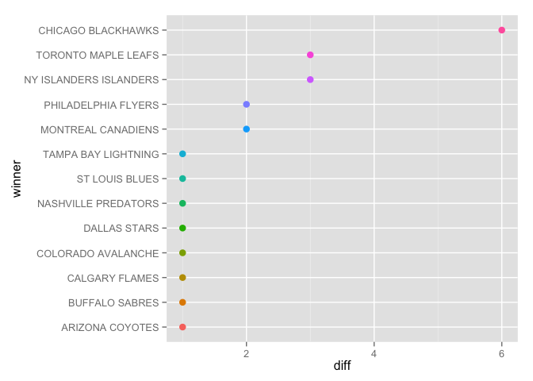

```r
suppressPackageStartupMessages(library(dplyr))
library(ggplot2)

win.dat <- score("2014-11-22") %>%
    mutate(winner = ifelse(home_score > away_score, as.character(home), as.character(away))) %>%
    mutate(diff = ifelse(home_score > away_score, home_score-away_score, away_score-home_score)) %>%
    mutate(winner = reorder(winner, diff)) %>%
    select(winner, diff) %>%
    ggplot(aes(diff, winner)) + geom_point(aes(colour = winner), size = 3) +
    theme(legend.position="none")
win.dat
```

Use the `gameday` package and stay up to date with your game-to-game needs.

## Reflections

Follow this [link](https://github.com/Dustin21/GP.Bagging) for the second part of this homework - I will attempt to build my own package.